# Project 2D: Submit Final R Notebook

## Introdruction

Scientific Question: Is it possible that the black Perigord truffle (Tuber melanosporum) and the Chinese black truffle (Tuber indicum) share similar protein expression profiles responsible for the production of the aromatic flavors such as 2 methylbutane? Black Truffle is a highly prized food today, with its unique scent (aroma) and texture. Howerver, Black Truffle remains relatively poorly studied, lacking “omics” information to characterize its biology and biochemistry (Tawhidul Islam). This rare ‘black diamond’ of the kitchen has long intrigued distinguished chefs and biologists alike, due to its combination of smooth texture, pungent odor/perfume, and musty earthy flavor (Mohamedali). A very rare and tresured Black Truffle is the Black Perigord Truffle. Closely related and commonly confused with perigord truffle is the Chinese Black Truffle. The European species Tuber melanosporum and the Asian species T. indicum are phylogenetically and morphologically very close (Chen). With interest in comparing (similarities/differences) of these two kinds of Black Truffle in their cost and aroma we will look into the properties they may be responsible for their aroma. As they are commonly confused as being the same kind of truffle it is possible that the Black Perigord Truffle and the Chinese Black Truffle have similar proteins involved in its aroma based on how they are similar species morphologically/physically. Thus, our scientific question focueses on the possibility of matching the enzyme 2 methylbutance for these two kinds of truffle.

Scientific Hypothesis: If the black Perigord truffle and the Chinese black truffle share similar protein expression profiles for their aromatic flavors, then volatiles and enzymes such as 2 methylbutane can be matched to the proteins obtained from these two truffles.

## Package Descriptions

```r
library(BiocManager)
library(Biostrings)
```

```r
library(seqinr)
```

```r
library(dplyr)
# Need to find an updated version or different package in order to do Protein Expression Analysis

library(DESeq2)
```

```r
library(taxonomizr)
```

```r
library(rBLAST)
```

```r
library(ggplot2)
```

## Performing Bioinformatics Analyses

Below, this code is responsible for loading in a fasta file for the two kinds of Truffle.

```r
library(seqinr)
T_melanosporum <- read.fasta(file = "T_melanosporum.fasta")
T_indicum <- read.fasta(file = "Tuber_Indicum.fasta")

seq <- readRNAStringSet(system.file("examples/RNA_example.fasta",
                        package="rBLAST"))
seq
```

```
RNAStringSet object of length 5:
    width seq                                                                                                    names
[1]  1481 AGAGUUUGAUCCUGGCUCAGAACGAACGCUGGCGGCGUGCCUAACACAUG...CUGCCUAAGGUAUGGCUGGUGAUCGGGGUGAAGUCGUAACAAGGUAACC 1675 AB015560.1 d...
[2]  1404 GCUGGCGGCAGGCCUAACACAUGCAAGUCGAACGGGGACCUUCGGGUCUU...GCUAACCCGCAAGGGAGGCAGCCGACCACGGUAAGGUCAGCGACUGGGG 4399 D14432.1 Rho...
[3]  1426 GGAAUGCUNAACACAUGCAAGUCGCACGGGCAGCAAUGUCAGUGGCGGAC...AGGGUCAGCGACUGGGGUGUAGUCGNAACAAGGUAGCCGUAGGGGAACC 4403 X72908.1 Ros...
[4]  1362 GCUGGCGGAAUGCUUAACACAUGCAAGUCGCACGGGGGUUUCGGCCUUAG...GCCCGUCACACCAUGGGAGUUGGUUUUACCUUAGGUGUCUAGGCUAACC 4404 AF173825.1 A...
[5]  1458 AGAGUUUGAUUAUGGCUCAGAGCGAACGCUGGCGGCAUGCUUAACACAUG...AACCACGGUCGGGUCAGCGACUGGGGUGAAGUCGUAACAAGGUAACCGU 4411 Y07647.2 Dre...
```

```r
## load a BLAST database (replace db with the location + name of the BLAST DB)
bl <- blast("T_melanosporum.fasta")
```

```
Error: Executable for blastn not found! Please make sure that the software is correctly installed and, if necessary, path variables are set.
```

```r
# The data is provided with the package
data <- T_melanosporum

# We filter for contaminant proteins and decoy database hits, which are indicated by "+" in the columns "Potential.contaminants" and "Reverse", respectively.
data <- filter(data, Reverse != "+", Potential.contaminant != "+")
```

```
Error in UseMethod("filter") :
  no applicable method for 'filter' applied to an object of class "list"
```

```r
colnames(data)
```

```r
data$Gene.names %>% duplicated() %>% any()
```

```
[1] FALSE
```

```r
# BLAST Search
# Setting Variables
#prepare for a BLAST query
dna <- readDNAStringSet('T_melanosporum.fasta', format='fastq')
```

```
Error in .Call2("read_fastq_files", filexp_list, nrec, skip, seek.first.rec,  :
  reading FASTQ file T_melanosporum.fasta: "@" expected at beginning of line 1
```

```r
# BLAST search
# Build taxonomizr database
ibdir='data'
dir.create(libdir)
```

```
Error in dir.create(libdir) : object 'libdir' not found
```

```r
# BLAST search
# Visualizing BLAST Hits
cltax=cbind(cl,taxlist) #bind BLAST hits and taxonomy table
```

```
Error in eval(quote(list(...)), env) : object 'cl' not found
```

```r
# Volcano Plot
#Example Volcano Plot - would apply combined Tuber Melonasporum and Tuber Indicum
# Download the data from github (click the "raw" button, save as a text file called "results.txt").
# https://gist.github.com/stephenturner/806e31fce55a8b7175af
res <- read.table("results.txt", header=TRUE)
head(res)
```

|  | Gene | log2FoldChange | pvalue | padj |
| --- | --- | --- | --- | --- |
| 1 | DOK6 | 0.5100 | 1.861e-08 | 0.0003053 |
| 2 | TBX5 | -2.1290 | 5.655e-08 | 0.0004191 |
| 3 | SLC32A1 | 0.9003 | 7.664e-08 | 0.0004191 |
| 4 | IFITM1 | -1.6870 | 3.735e-06 | 0.0068090 |
| 5 | NUP93 | 0.3659 | 3.373e-06 | 0.0068090 |
| 6 | EMILIN2 | 1.5340 | 2.976e-06 | 0.0068090 |

```r
# Make a basic volcano plot
with(res, plot(log2FoldChange, -log10(pvalue), pch=20, main="Volcano plot", xlim=c(-2.5,2)))

# Add colored points: red if padj<0.05, orange of log2FC>1, green if both)
with(subset(res, padj<.05 ), points(log2FoldChange, -log10(pvalue), pch=20, col="red"))
```

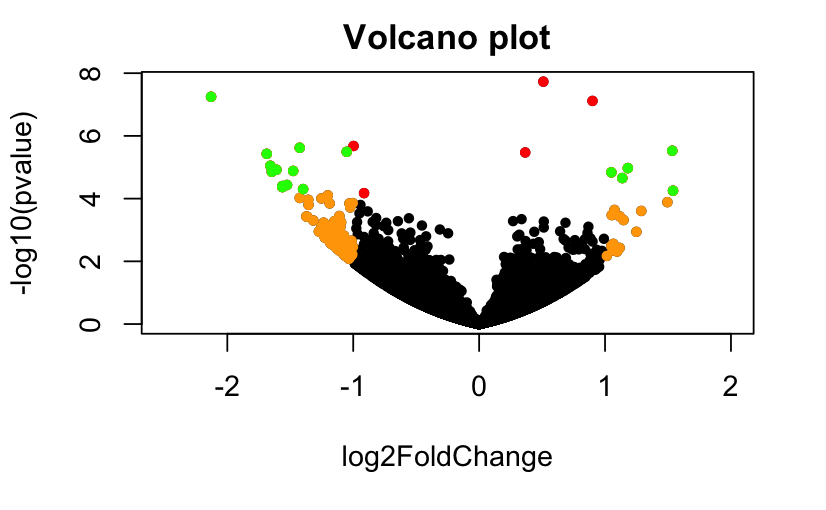

```r
with(subset(res, abs(log2FoldChange)>1), points(log2FoldChange, -log10(pvalue), pch=20, col="orange"))
with(subset(res, padj<.05 & abs(log2FoldChange)>1), points(log2FoldChange, -log10(pvalue), pch=20, col="green"))
```

```r
# Plot a volcano plot for the contrast "Ubi6 vs Ctrl""
plot_volcano(dep, contrast = "Tuber_melanosporum_vs_Tuber_Indicum", label_size = 2, add_names = TRUE)
```

```
Error in plot_volcano(dep, contrast = "Tuber_melanosporum_vs_Tuber_Indicum",  :
  could not find function "plot_volcano"
```

```r
# Phylogenetic Clustering
library(RRphylo)
data("DataFelids")
DataFelids$treefel->treefel
DataFelids$statefel->statefel

phyloclust(tree=treefel,state=statefel,focal="saber")
```

[output not shown]

```r
data("T_combined")
DataFelids$treefel->treefel
DataFelids$statefel->statefel

phyloclust(tree=treefel,state=statefel,focal="saber")
```

[output not shown]

## Analysis of Results

With difficulty in coding and loading the correct packages and data, I was unable to plot/visualize my planned bioinformatic analyses. I unsuccessfully perfomred my bioinformtic analyses which I intended to perfrom/include protein expression analysis, BLAST search and use a volcano plot and phylogenetic clustering to visualize the similarity of the truffle genome/sequence alignment respectively. However, if I was able to perfrom this successfully, I would expect to see similarity f the truffle genome/sequence alignment in which the two kinds of truffle also share similar enzymes and volatiles, specifically 2 methylbutane. 2-methyl-butanal is one of the important volatiles produced by truffles. There are differences in the production of 2-methyl-butanal in different truffle specimen, in which the sequences would have considerable variety across the different Truffle species. If I had done this properly, I would expect to see higher production levels of 2 methylbutane in Tuber melanosporum (Black Perigord Truffle) while Tuber Indicum (Chinese Black Truffle) also contains levels of 2 methylbutane but much less that Tuber melanosporum. Therefore, it is also expected that Black Perigord Truffle’s enzyme sequences would be the most divergent from Chinese Black Truffle and other types of Truffle as well.